# #Red Wine Quality Exploration by Wei Chai

### fixed.acidity

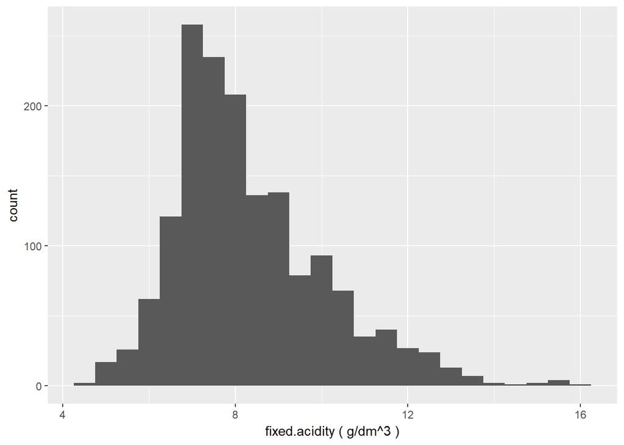

```
##    Min. 1st Qu.  Median    Mean 3rd Qu.    Max.
##    4.60    7.10    7.90    8.32    9.20   15.90
```

大部分红酒的fixed.acidity的值大约在7-9的范围内，最小值为4.6，最大值为15.9, fixed.acidity呈现偏态分布。

### volatile.acidity

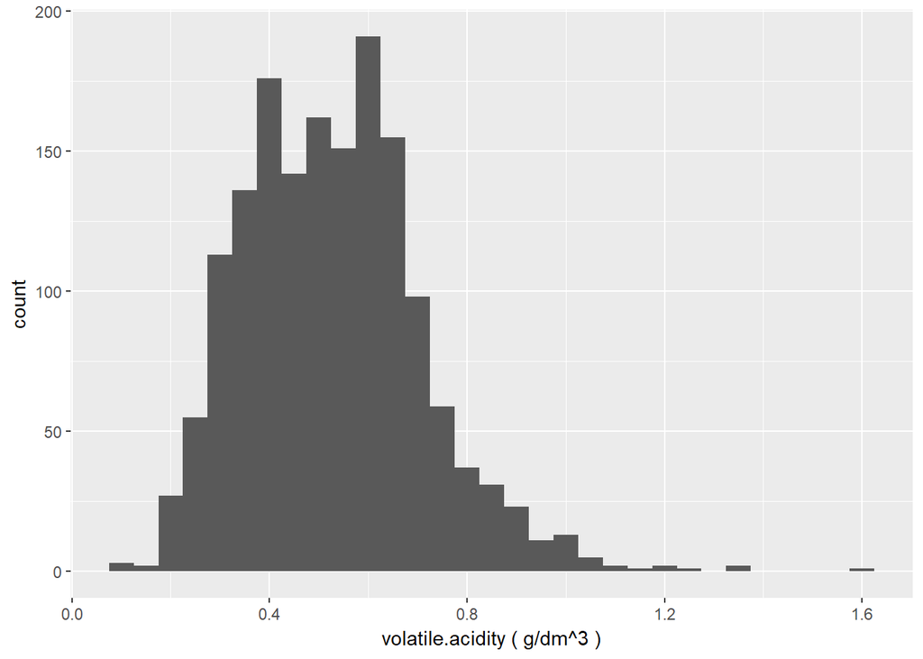

```
##    Min. 1st Qu.  Median    Mean 3rd Qu.    Max.
##  0.1200  0.3900  0.5200  0.5278  0.6400  1.5800
```

可以看出大部分的红酒的volatile.acidity值都在0.4-0.6左右，而且很少有超过1.0，最小值为0.12，最大值为1.58，volatile.acidity呈现正态分布。

### citric.acid

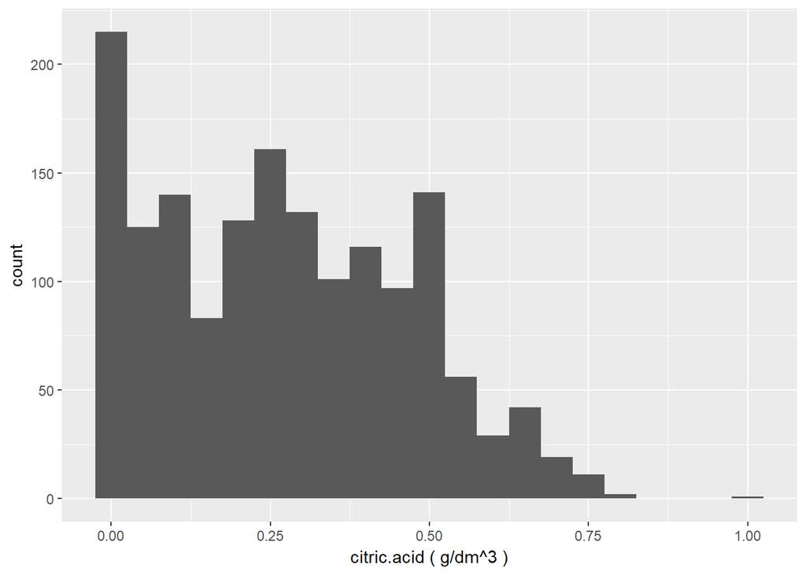

```
##    Min. 1st Qu.  Median    Mean 3rd Qu.    Max.
##   0.000   0.090   0.260   0.271   0.420   1.000
```

大部分红酒的citric.acid值都很低，普遍低于0.5，而且最多的是值为0，citric.acid呈现偏态分布。

### residual.sugar

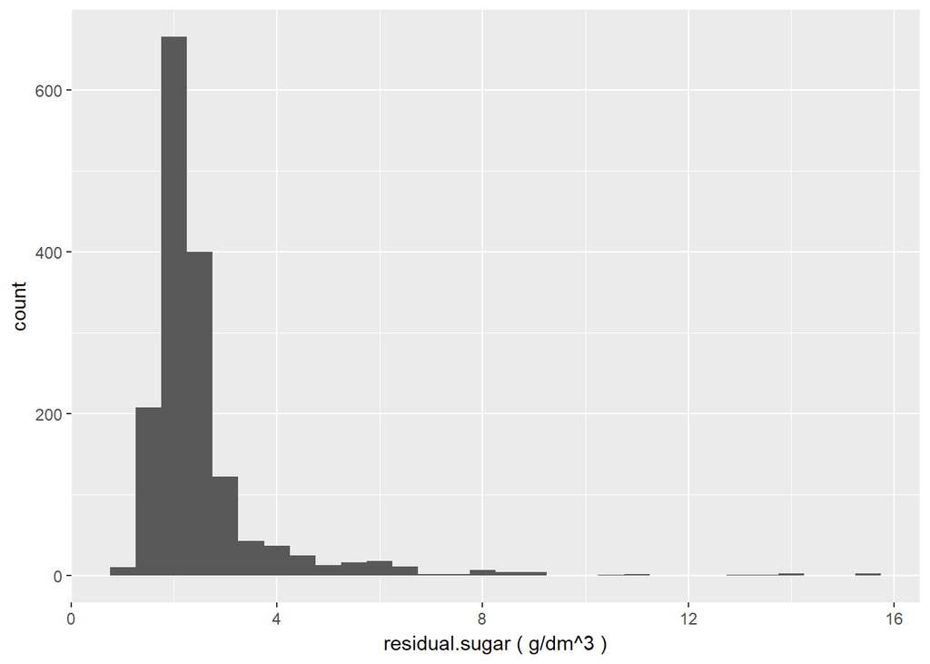

```
##    Min. 1st Qu.  Median    Mean 3rd Qu.    Max.
##   0.900   1.900   2.200   2.539   2.600  15.500
```

大部分红酒的residual.sugar值都很低，基本处于1-3范围内,但是有某些值很大，最大值为15.5，residual.sugar呈现长尾分布。

### chlorides

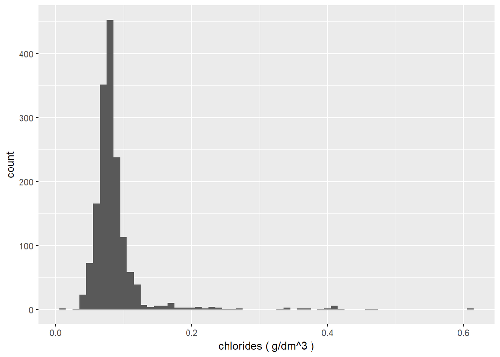

```
##    Min. 1st Qu.  Median    Mean 3rd Qu.    Max.
## 0.01200 0.07000 0.07900 0.08747 0.09000 0.61100
```

红酒的chlorides值主要集中在0.1附近，基本上都低于0.2，最小值为0.012，最大值为0.611，chlorides总体呈现长尾分布。

### free.sulfur.dioxide

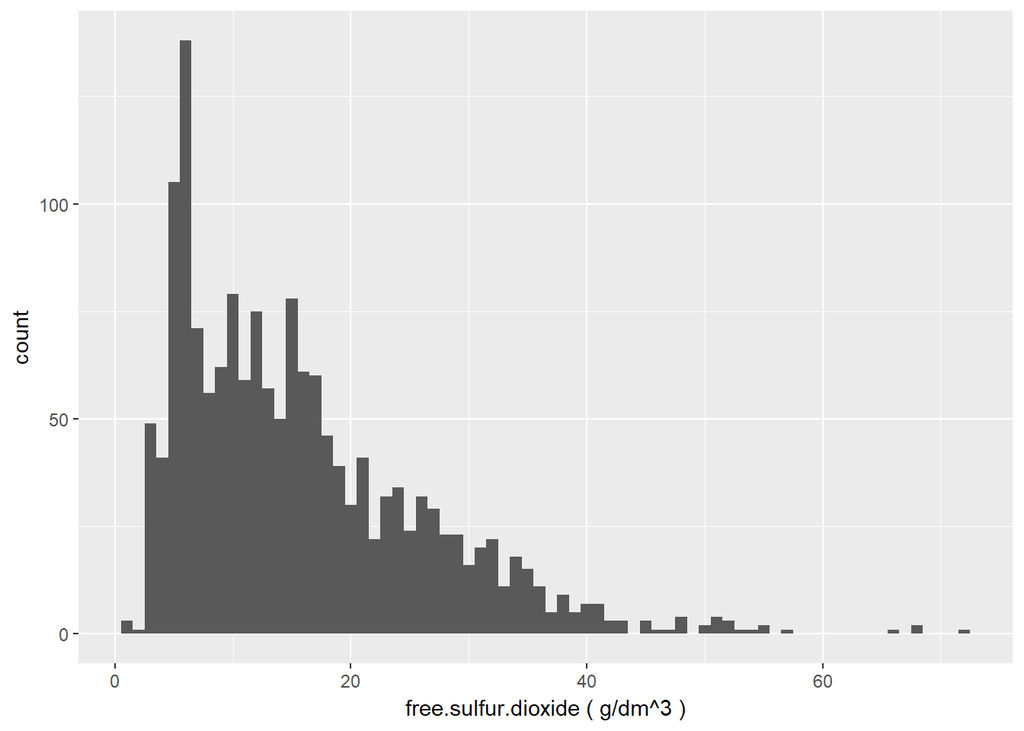

```
##    Min. 1st Qu.  Median    Mean 3rd Qu.    Max.
##    1.00    7.00   14.00   15.87   21.00   72.00
```

大部分红酒的free.sulfur.dioxide的值都低于20，最小值为1，最大值为72，free.sulfur.dioxide呈现偏态分布。

### total.sulfur.dioxide

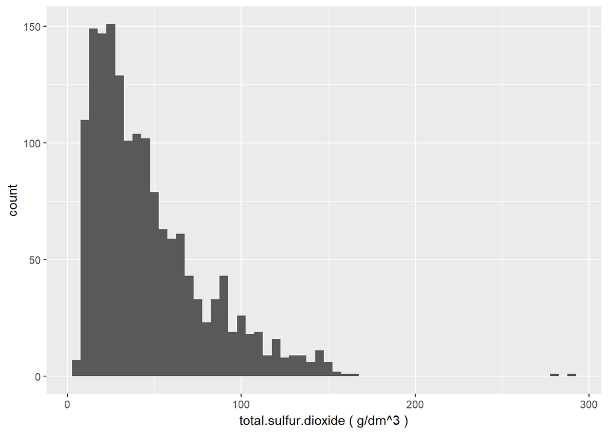

```
##    Min. 1st Qu.  Median    Mean 3rd Qu.    Max.
##    6.00   22.00   38.00   46.47   62.00  289.00
```

可以看出大部分红酒的total.sulfur.dioxide值都低于100，只有少数的值异常地高，最小值为6，最大值为289，呈现偏态分布。

### density

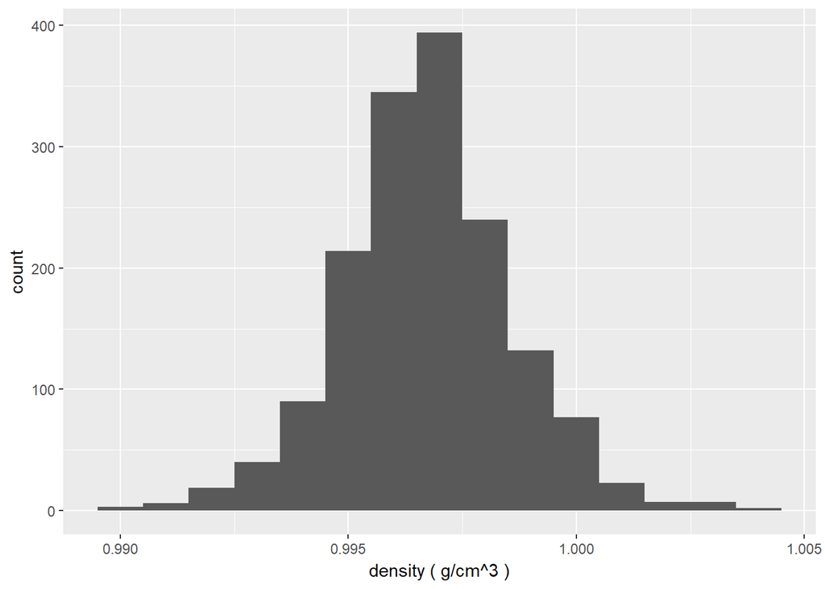

```
##    Min. 1st Qu.  Median    Mean 3rd Qu.    Max.
##  0.9901  0.9956  0.9968  0.9967  0.9978  1.0037
```

可以看出红酒的密度跟水差不多，大部分要稍微低于水，集中在0.995-1之间，density呈现正态分布。

### pH

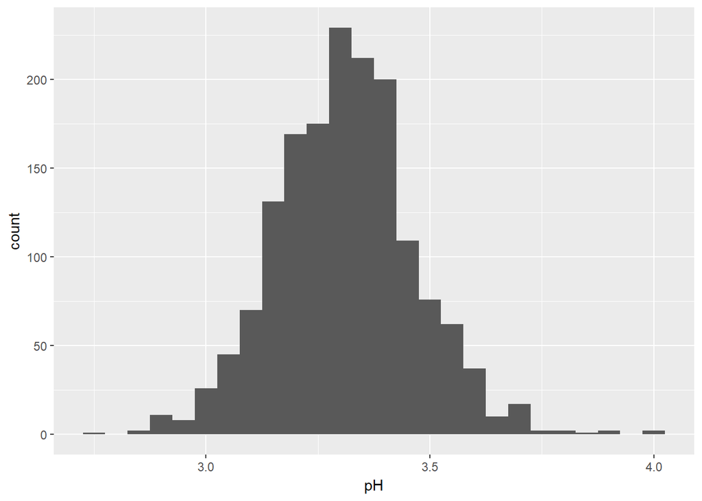

```
##    Min. 1st Qu.  Median    Mean 3rd Qu.    Max.
##   2.740   3.210   3.310   3.311   3.400   4.010
```

可以看出红酒呈酸性，pH值大部分在3.0-3.5之间，pH呈现正态分布。

### sulphates

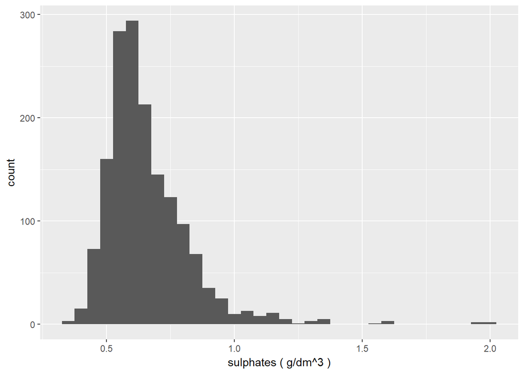

```
##    Min. 1st Qu.  Median    Mean 3rd Qu.    Max.
##  0.3300  0.5500  0.6200  0.6581  0.7300  2.0000
```

可以看出大部分红酒的sulphates值在0.5-0.7之间，最小值为0.33，最大值为2，sulphates呈现偏态分布。

### alcohol

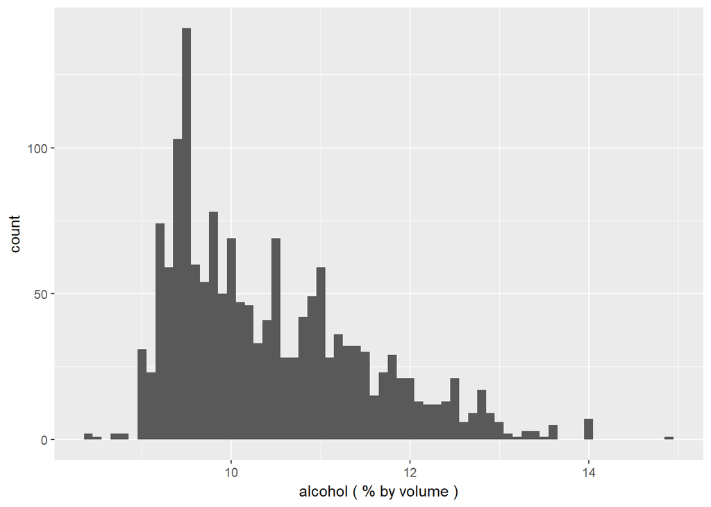

```
##    Min. 1st Qu.  Median    Mean 3rd Qu.    Max.
##    8.40    9.50   10.20   10.42   11.10   14.90
```

大部分红酒的alcohol值在9-11度左右,最小值为8.4，最大值为14.9，alcohol呈现偏态分布。

### new variable total.acidity

wineQualityReds <- wineQualityReds %>% mutate(total.acidity = fixed.acidity + volatile.acidity)

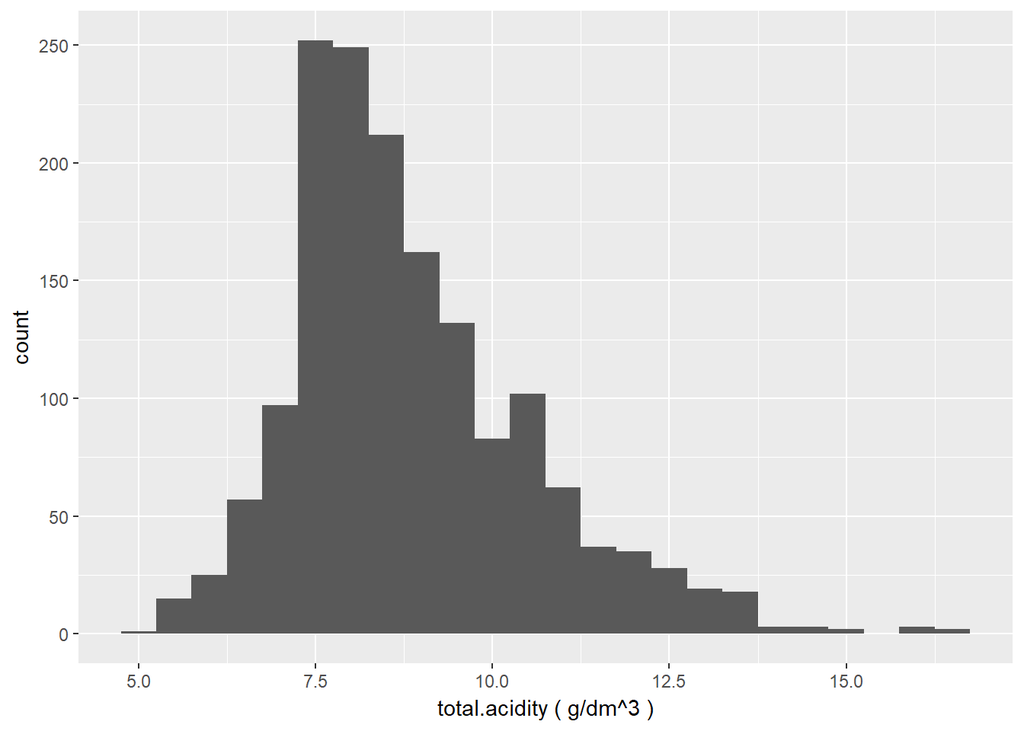

```
##    Min. 1st Qu.  Median    Mean 3rd Qu.    Max.
##   5.120   7.680   8.445   8.847   9.740  16.285
```

total.acidity的最小值为5.12，最大值为16.285，大部分数据都在7-11这个范围内，total.acidity呈现偏态分布。

# 单变量分析

### 你的数据集结构是什么？

一共1599个红酒数据，其中有13个变量（fixed.acidity, volatile.acidity, citric.acid, residual.sugar, chlorides, free.sulfur.dioxide, total.sulfur.dioxide, density, pH, sulphates, alcohol, quality, total.acidity）,其中total.acidity为新创建的变量。

部分观察结果：

- 大部分红酒的quality为5分和6分。
- 大部分红酒的fixed.acidity值在7-9的范围内。
- 大部分的红酒的volatile.acidity值都在0.4-0.6左右。
- 大部分红酒的citric.acid值都很低，普遍低于0.5，而且最多的是值为0。
- 大部分红酒的residual.sugar值都很低，基本处于1-3范围内。
- 红酒的chlorides值主要集中在0.1附近，基本上都低于0.2。
- 大部分红酒的free.sulfur.dioxide的值都低于20。
- 大部分红酒的total.sulfur.dioxide值都低于100。
- 红酒的密度跟水差不多，大部分要稍微低于水。
- 红酒呈酸性，pH值大部分在3.0-3.5之间。
- 大部分红酒的alcohol值在9-11度左右。

### 你的数据集内感兴趣的主要特性有哪些？

我感兴趣的特性是alcohol，residual.sugar和quality，我怀疑可以通过使用alcohol和residual.sugar以及一些其他特性的组合来预测quality。

### 你认为数据集内哪些其他特征可以帮助你探索兴趣特点？

我认为volatile.acidity，citric.acid，total.sulfur.dioxide都有可能会对quality造成影响。

### 根据数据集内已有变量，你是否创建了任何新变量？

创建了一个新变量total.acidity，因为已有fixed.acidity和volatile.acidity，所以就顺势地创建了总体的acidity变量。

### 在已经探究的特性中，是否存在任何异常分布？你是否对数据进行一些操作，如清洁、调整或改变数据的形式？如果是，你为什么会这样做？

从上面各个图形中可以看出，residual.sugar,chlorides以及total.sulfur.dioxide中都存在一些很大的值。  
在读取数据的时候将索引列X给去除了，因为这并不是我们所需要的数据。当然之后也没有对数据进行调整，是因为没有发现一些比较明显的错误，在后续的分析中，会根据实际情况来看是否要去调整火改变数据的形式。

# 双变量绘图选择

```
##                      fixed.acidity volatile.acidity citric.acid
## fixed.acidity           1.00000000     -0.256130895  0.67170343
## volatile.acidity       -0.25613089      1.000000000 -0.55249568
## citric.acid             0.67170343     -0.552495685  1.00000000
## residual.sugar          0.11477672      0.001917882  0.14357716
## chlorides               0.09370519      0.061297772  0.20382291
## free.sulfur.dioxide    -0.15379419     -0.010503827 -0.06097813
## total.sulfur.dioxide   -0.11318144      0.076470005  0.03553302
## density                 0.66804729      0.022026232  0.36494718
## pH                     -0.68297819      0.234937294 -0.54190414
## sulphates               0.18300566     -0.260986685  0.31277004
## alcohol                -0.06166827     -0.202288027  0.10990325
## quality                 0.12405165     -0.390557780  0.22637251
## total.acidity           0.99482800     -0.156620601  0.62825187
##                      residual.sugar    chlorides free.sulfur.dioxide
## fixed.acidity           0.114776724  0.093705186        -0.153794193
## volatile.acidity        0.001917882  0.061297772        -0.010503827
## citric.acid             0.143577162  0.203822914        -0.060978129
## residual.sugar          1.000000000  0.055609535         0.187048995
## chlorides               0.055609535  1.000000000         0.005562147
## free.sulfur.dioxide     0.187048995  0.005562147         1.000000000
## total.sulfur.dioxide    0.203027882  0.047400468         0.667666450
## density                 0.355283371  0.200632327        -0.021945831
## pH                     -0.085652422 -0.265026131         0.070377499
## sulphates               0.005527121  0.371260481         0.051657572
## alcohol                 0.042075437 -0.221140545        -0.069408354
## quality                 0.013731637 -0.128906560        -0.050656057
## total.acidity           0.117473729  0.102183639        -0.158241719
##                      total.sulfur.dioxide     density          pH
## fixed.acidity                 -0.11318144  0.66804729 -0.68297819
## volatile.acidity               0.07647000  0.02202623  0.23493729
## citric.acid                    0.03553302  0.36494718 -0.54190414
## residual.sugar                 0.20302788  0.35528337 -0.08565242
## chlorides                      0.04740047  0.20063233 -0.26502613
## free.sulfur.dioxide            0.66766645 -0.02194583  0.07037750
## total.sulfur.dioxide           1.00000000  0.07126948 -0.06649456
## density                        0.07126948  1.00000000 -0.34169933
## pH                            -0.06649456 -0.34169933  1.00000000
## sulphates                      0.04294684  0.14850641 -0.19664760
## alcohol                       -0.20565394 -0.49617977  0.20563251
## quality                       -0.18510029 -0.17491923 -0.05773139
## total.acidity                 -0.10760684  0.68488647 -0.67314051
##                         sulphates     alcohol     quality total.acidity
## fixed.acidity         0.183005664 -0.06166827  0.12405165    0.99482800
## volatile.acidity     -0.260986685 -0.20228803 -0.39055778   -0.15662060
## citric.acid           0.312770044  0.10990325  0.22637251    0.62825187
## residual.sugar        0.005527121  0.04207544  0.01373164    0.11747373
## chlorides             0.371260481 -0.22114054 -0.12890656    0.10218364
## free.sulfur.dioxide   0.051657572 -0.06940835 -0.05065606   -0.15824172
## total.sulfur.dioxide  0.042946836 -0.20565394 -0.18510029   -0.10760684
## density               0.148506412 -0.49617977 -0.17491923    0.68488647
## pH                   -0.196647602  0.20563251 -0.05773139   -0.67314051
## sulphates             1.000000000  0.09359475  0.25139708    0.15956033
## alcohol               0.093594750  1.00000000  0.47616632   -0.08426530
## quality               0.251397079  0.47616632  1.00000000    0.08570932
## total.acidity         0.159560329 -0.08426530  0.08570932    1.00000000
```

从上述计算得到的相关系数上来看，并没有哪个特性与quality呈现强相关，比较相关的特性依次有alcohol，volatile.acidity，sulphates，citric.acid。

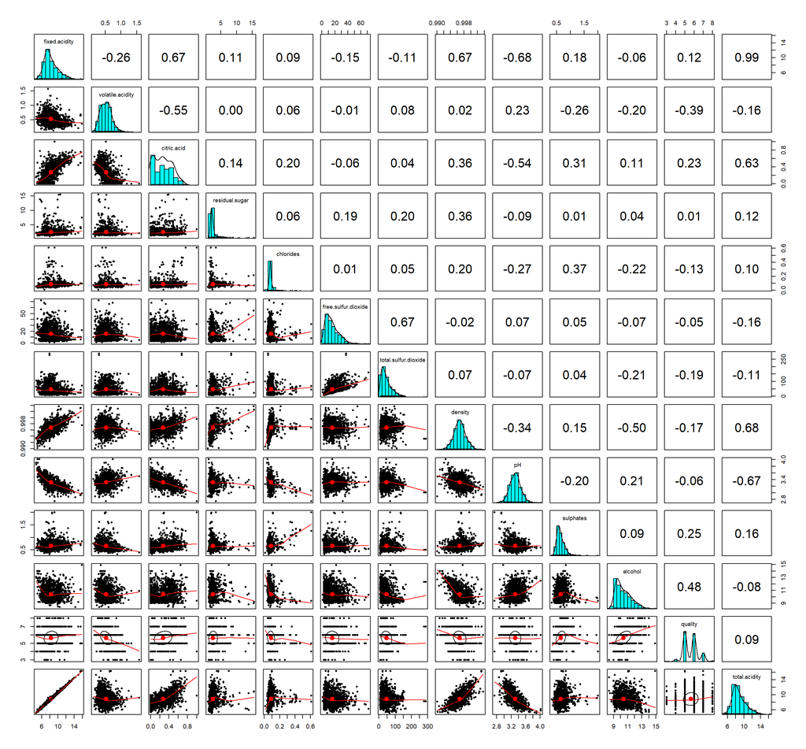

从上面的图中，可以更加清楚地看出各个特性之间的散点图分布，以及相关系数。除了之前提及到的与quality有关的特性之外，还可以看出density与alcohol有着弱相关性，fixed.acidity、volatile.acidity和citric.acid之间有比较强的相关性，chlorides、citric.acid和sulphates有着弱相关，当然还有一些其他的特性之间有着某种相关性，比如density和fixed.acidity，但是在这里我只关心有可能影响quality的，下面将详细地去探索这些特性之间的关系。

## quality & alcohol

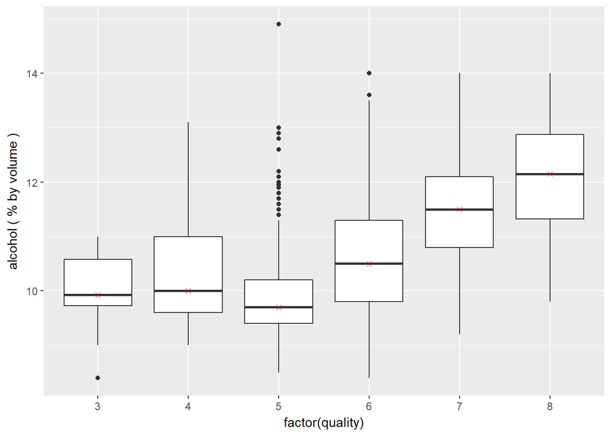

```
## wineQualityReds$quality: 3
##    Min. 1st Qu.  Median    Mean 3rd Qu.    Max.
##   8.400   9.725   9.925   9.955  10.575  11.000
## --------------------------------------------------------
## wineQualityReds$quality: 4
##    Min. 1st Qu.  Median    Mean 3rd Qu.    Max.
##    9.00    9.60   10.00   10.27   11.00   13.10
## --------------------------------------------------------
## wineQualityReds$quality: 5
##    Min. 1st Qu.  Median    Mean 3rd Qu.    Max.
##     8.5     9.4     9.7     9.9    10.2    14.9
## --------------------------------------------------------
## wineQualityReds$quality: 6
##    Min. 1st Qu.  Median    Mean 3rd Qu.    Max.
##    8.40    9.80   10.50   10.63   11.30   14.00
## --------------------------------------------------------
## wineQualityReds$quality: 7
##    Min. 1st Qu.  Median    Mean 3rd Qu.    Max.
##    9.20   10.80   11.50   11.47   12.10   14.00
## --------------------------------------------------------
## wineQualityReds$quality: 8
##    Min. 1st Qu.  Median    Mean 3rd Qu.    Max.
##    9.80   11.32   12.15   12.09   12.88   14.00
```

从上述结果来看，由于quality值为3，4还有8的数量很少，因此总体上alcohol的值越大，quality值越大，两者呈正相关。

## quality & volatile.acidity

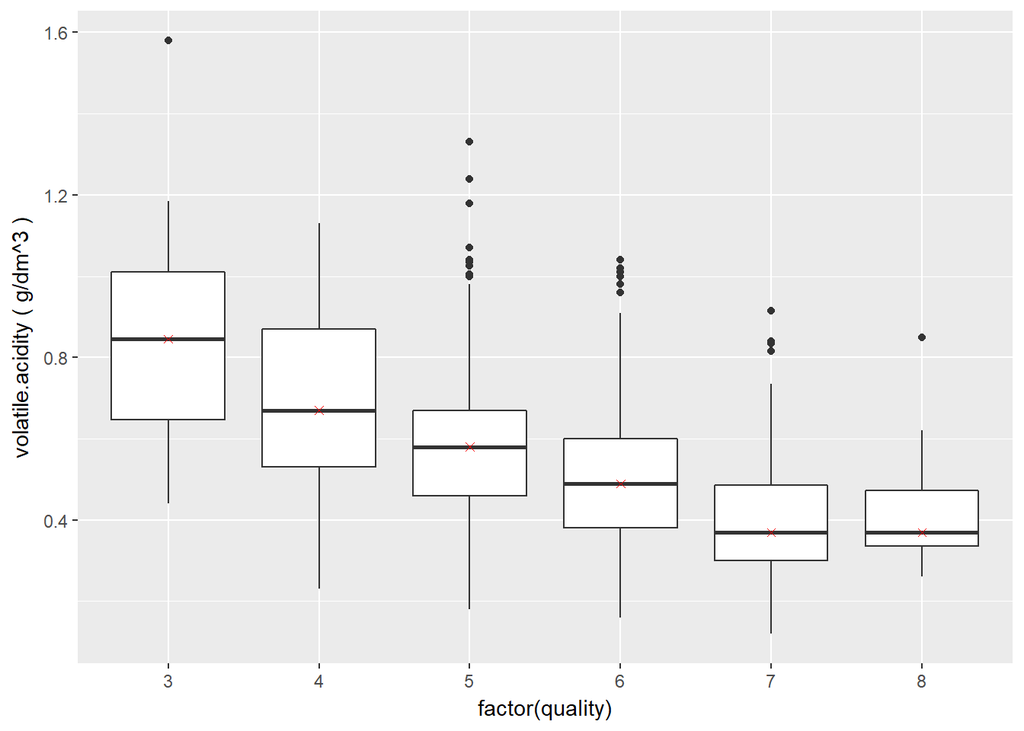

```
## wineQualityReds$quality: 3
##    Min. 1st Qu.  Median    Mean 3rd Qu.    Max.
##  0.4400  0.6475  0.8450  0.8845  1.0100  1.5800
## --------------------------------------------------------
## wineQualityReds$quality: 4
##    Min. 1st Qu.  Median    Mean 3rd Qu.    Max.
##   0.230   0.530   0.670   0.694   0.870   1.130
## --------------------------------------------------------
## wineQualityReds$quality: 5
##    Min. 1st Qu.  Median    Mean 3rd Qu.    Max.
##   0.180   0.460   0.580   0.577   0.670   1.330
## --------------------------------------------------------
## wineQualityReds$quality: 6
##    Min. 1st Qu.  Median    Mean 3rd Qu.    Max.
##  0.1600  0.3800  0.4900  0.4975  0.6000  1.0400
## --------------------------------------------------------
## wineQualityReds$quality: 7
##    Min. 1st Qu.  Median    Mean 3rd Qu.    Max.
##  0.1200  0.3000  0.3700  0.4039  0.4850  0.9150
## --------------------------------------------------------
## wineQualityReds$quality: 8
##    Min. 1st Qu.  Median    Mean 3rd Qu.    Max.
##  0.2600  0.3350  0.3700  0.4233  0.4725  0.8500
```

可以看出总体上volatile.acidity的值越小，quality值越大，两者呈弱负相关。

## quality & sulphates

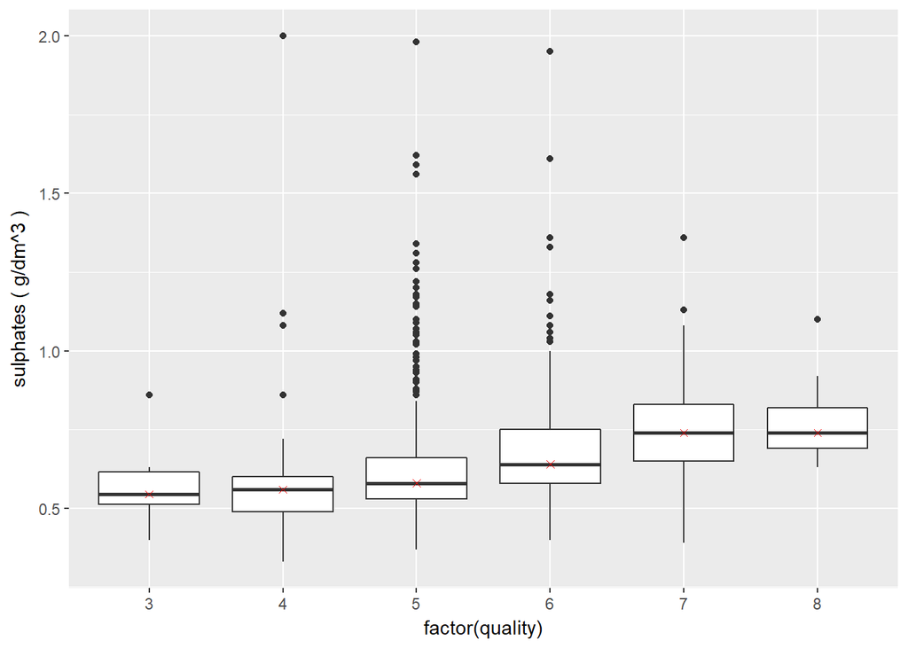

```
## wineQualityReds$quality: 3
##    Min. 1st Qu.  Median    Mean 3rd Qu.    Max.
##  0.4000  0.5125  0.5450  0.5700  0.6150  0.8600
## --------------------------------------------------------
## wineQualityReds$quality: 4
##    Min. 1st Qu.  Median    Mean 3rd Qu.    Max.
##  0.3300  0.4900  0.5600  0.5964  0.6000  2.0000
## --------------------------------------------------------
## wineQualityReds$quality: 5
##    Min. 1st Qu.  Median    Mean 3rd Qu.    Max.
##   0.370   0.530   0.580   0.621   0.660   1.980
## --------------------------------------------------------
## wineQualityReds$quality: 6
##    Min. 1st Qu.  Median    Mean 3rd Qu.    Max.
##  0.4000  0.5800  0.6400  0.6753  0.7500  1.9500
## --------------------------------------------------------
## wineQualityReds$quality: 7
##    Min. 1st Qu.  Median    Mean 3rd Qu.    Max.
##  0.3900  0.6500  0.7400  0.7413  0.8300  1.3600
## --------------------------------------------------------
## wineQualityReds$quality: 8
##    Min. 1st Qu.  Median    Mean 3rd Qu.    Max.
##  0.6300  0.6900  0.7400  0.7678  0.8200  1.1000
```

可以看出sulphates的值越大，quality的值越大，两者呈弱正相关。

## quality & citric.acid

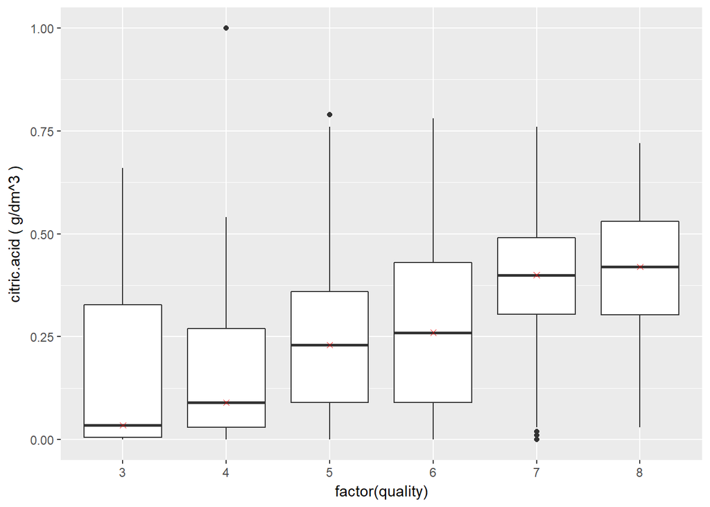

```
## wineQualityReds$quality: 3
##    Min. 1st Qu.  Median    Mean 3rd Qu.    Max.
##  0.0000  0.0050  0.0350  0.1710  0.3275  0.6600
## --------------------------------------------------------
## wineQualityReds$quality: 4
##    Min. 1st Qu.  Median    Mean 3rd Qu.    Max.
##  0.0000  0.0300  0.0900  0.1742  0.2700  1.0000
## --------------------------------------------------------
## wineQualityReds$quality: 5
##    Min. 1st Qu.  Median    Mean 3rd Qu.    Max.
##  0.0000  0.0900  0.2300  0.2437  0.3600  0.7900
## --------------------------------------------------------
## wineQualityReds$quality: 6
##    Min. 1st Qu.  Median    Mean 3rd Qu.    Max.
##  0.0000  0.0900  0.2600  0.2738  0.4300  0.7800
## --------------------------------------------------------
## wineQualityReds$quality: 7
##    Min. 1st Qu.  Median    Mean 3rd Qu.    Max.
##  0.0000  0.3050  0.4000  0.3752  0.4900  0.7600
## --------------------------------------------------------
## wineQualityReds$quality: 8
##    Min. 1st Qu.  Median    Mean 3rd Qu.    Max.
##  0.0300  0.3025  0.4200  0.3911  0.5300  0.7200
```

可以看出citric.acid的值越大，quality的值越大，两者呈弱正相关。

## density & alcohol

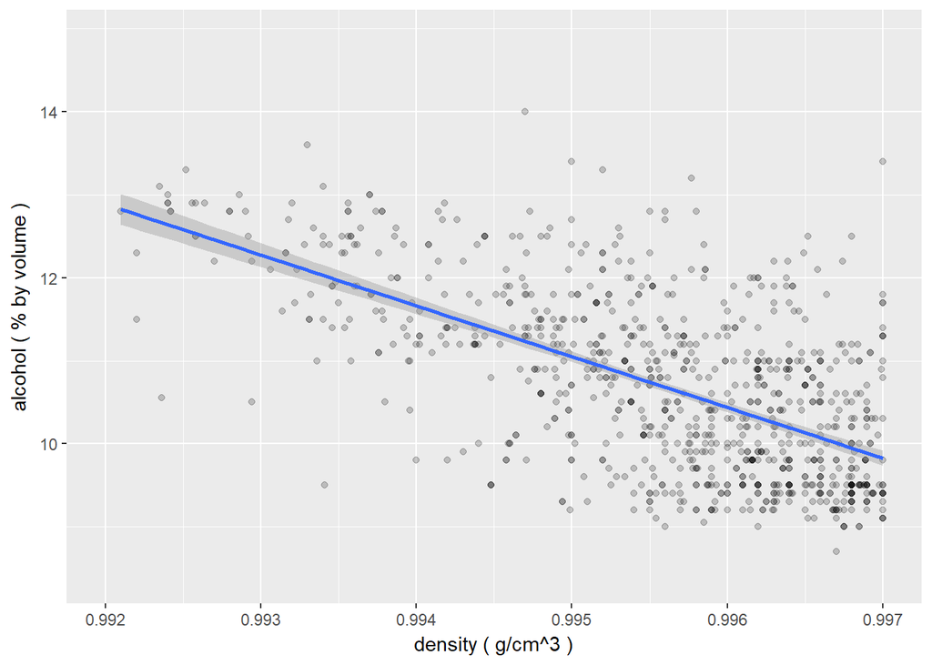

可以看出随着density的增大，alcohol减小，两者呈负相关。

## fixed.acidity & citric.acid

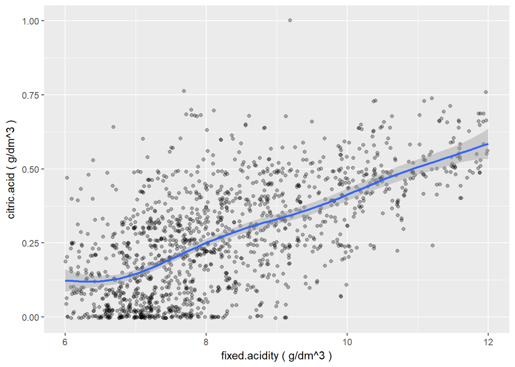

可以看出随着fixed.acidity的值增大，citric.acid的值也在增大，两者呈正相关。

## volatile.acidity & citric.acid

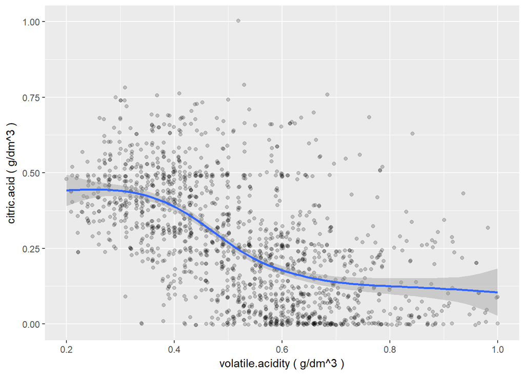

可以看出随着volatile.acidity的增大，citric.acid在减小，两者呈负相关。

## chlorides & sulphates

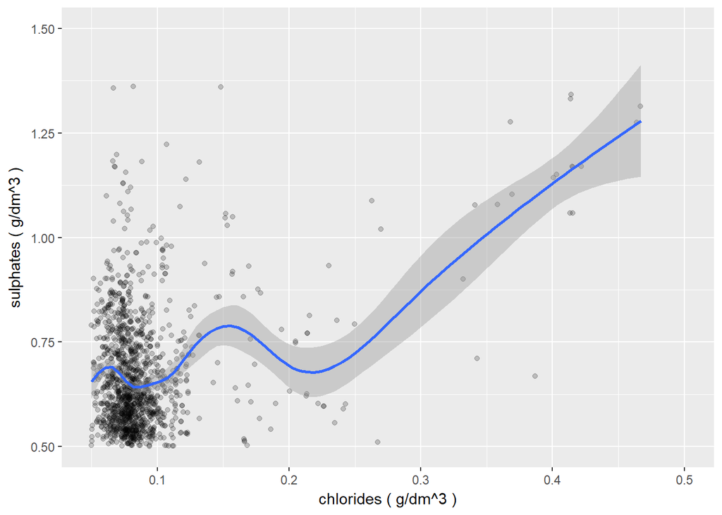

总体上来看chlorides的值越大，sulphates的值越大，两者呈正相关，但是图中来看聚集在一起的点很多，需要引起注意。

## citric.acid & sulphates

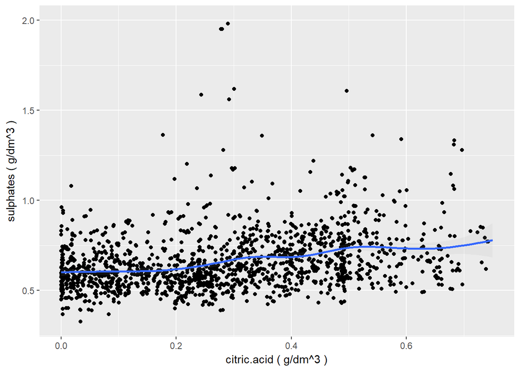

可以看出随着citric.acid的增大，sulphates的值也变大，两者呈正相关。

# 双变量分析

### 探讨你在这部分探究中观察到的一些关系。这些感兴趣的特性与数据集内其他特性有什么区别？

在这部分我发现红酒的质量quality与alcohol，sulphates和citric.acid呈正相关性，与volatile.acidity呈负相关性，其中quality与alcohol的相关性最强。这些特性相比其他特性更加能够影响红酒的质量，也就是说对味道，口感之类的影响较大。当然这些特性与其他特性之间也是有着一些关系的，从上面的研究中可以发现density与alcohol呈负相关，volatile.acidity与citric.acid呈负相关，fixed.acidity，sulphates与citric.acid呈正相关，chlorides与sulphates呈正相关。

### 你是否观察到主要特性与其他特性之间的有趣关系？

在未进行双变量分析之前，我认为alcohol，residual.sugar会对quality造成比较大的影响，但是从相关系数上来看，residual.sugar并未对quality造成比较大的影响，有点出乎意料。

### 你发现最强的关系是什么？

我发现的最强的关系是我新创建的变量total.acidity与fixed.acidity，相关系数为0.9948。当然这也很容易去解释，这是因为total.acidity是fixed.acidity与volatile.acidity两者之和，而且fixed.acidity的值远大于volatile.acidity。

# 多变量绘图选择

从上面的探讨中我们可以知道影响quality的特性有alcohol，volatile.acidity，sulphates，citric.acid，下面继续深入地的探讨这几者之间的关系。

## quality & alcohol & volatile.acidity

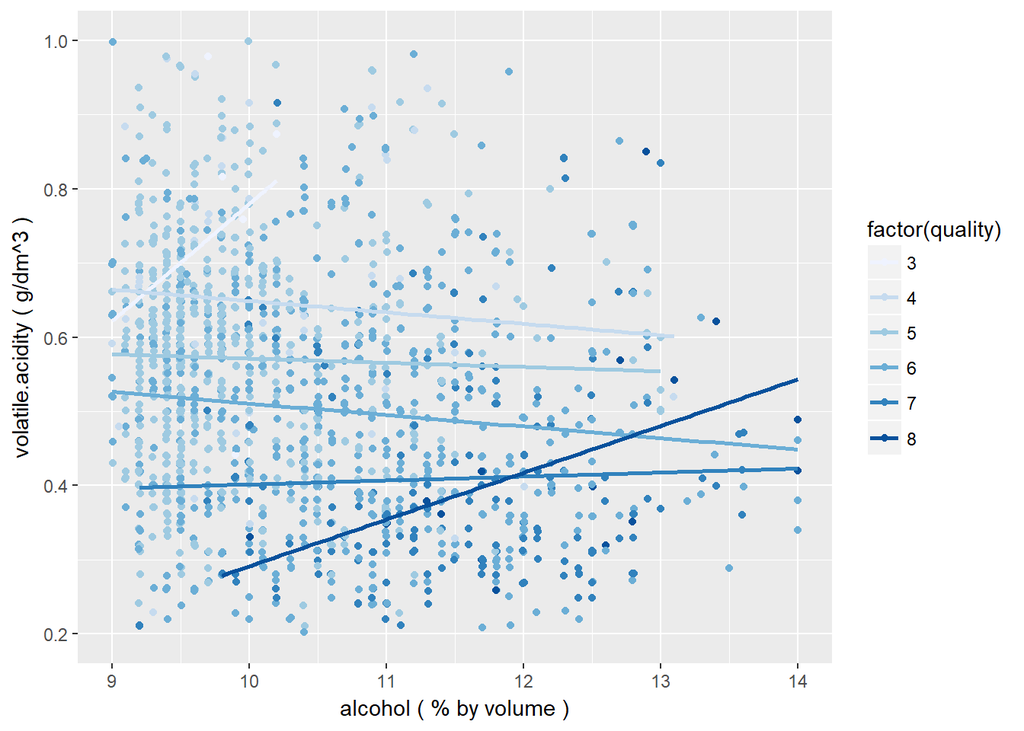

从图中可以看出随着alcohol的值增大，fator值大的点数也在变多；然而volatile.acidity值大的区域内，factor值小的点数比较多，这也正与前面观察到的现象一致，quality与alcohol呈正相关性，与volatile.acidity呈负相关性。alcohol与volatile.acidity之间的关系，从图中来看既有上升的也有下降的直线，但考虑到factor值为5和6的数目比较多，因此两者应该也是呈比较弱的负相关。

## quality & alcohol & sulphates

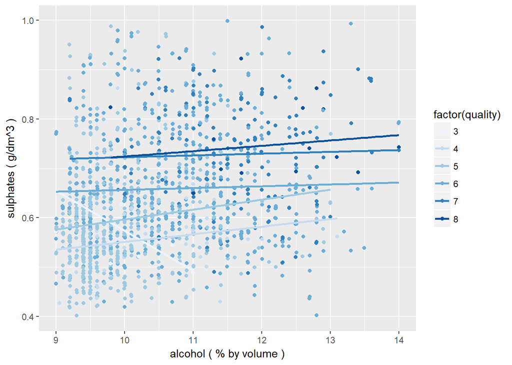

## quality & alcohol & citric.acid

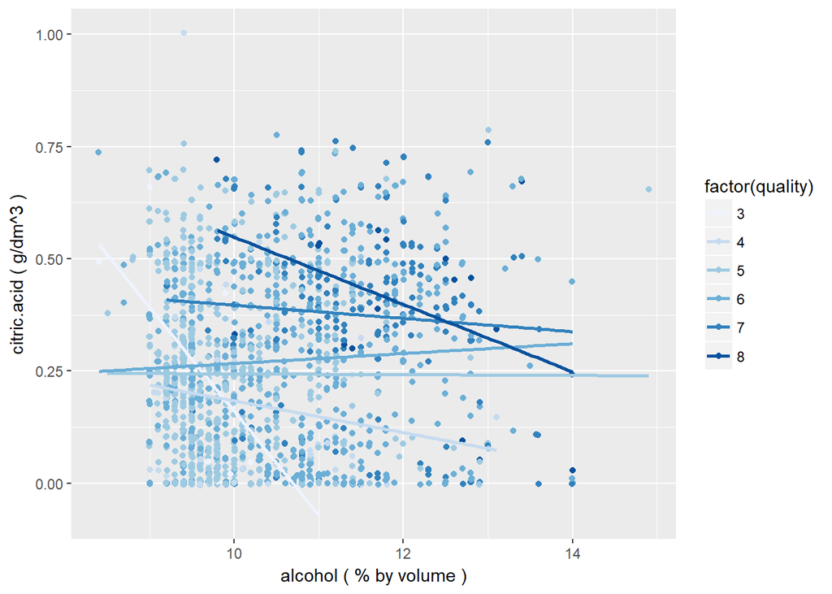

同上，从图中可以看出随着alcohol的值增大，fator值大的点数也在变多；随着citric.acid值的变大，quality值大的拟合线也基本高于值小的拟合线。也就是说，alcohol、citric.acid和fator呈正相关。alcohol和citric.acid之间的相关性从图中来看并不是很明显。

## quality & volatile.acidity & sulphates

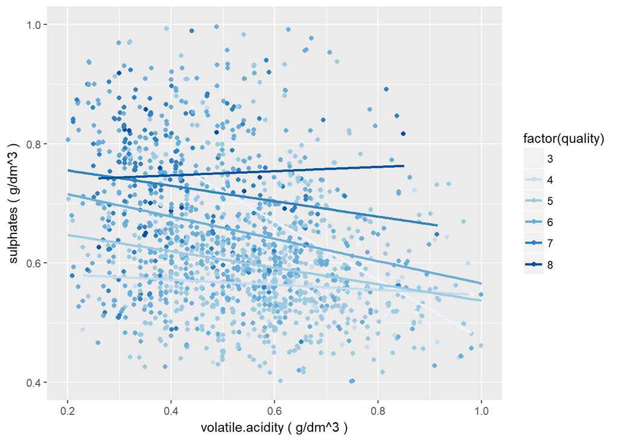

在之前的分析中我们已经知道volatile.acidity与quality呈负相关，sulphates与quality呈正相关。从图中可以看出，随着volatile.acidity值的增大，sulphates的值在减小，也就是说两者呈负相关。

## quality & volatile.acidity & citric.acid

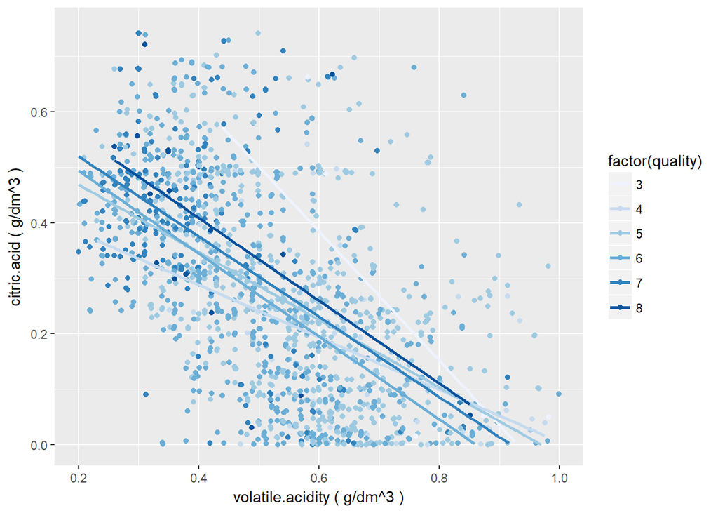

同理,volatile.acidity、citric.acid和quality的关系之间分析过，在此不分析。从图中来看，随着volatile.acidity值增大，citric.acid值在减小，两者呈负相关，而且从斜率上来看，中等强度负相关。

## quality & sulphates & citric.acid

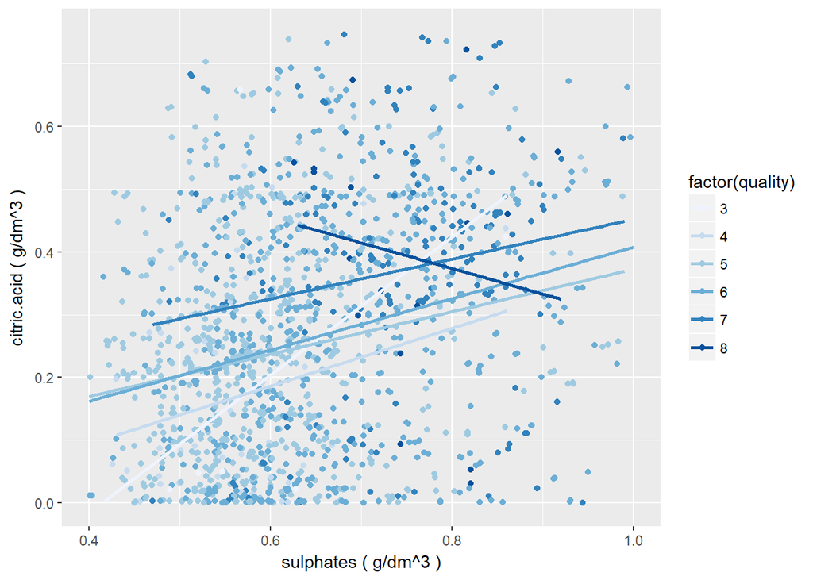

还是同理，sulphates、citric.acid和quality的关系之间分析过，在此不分析。从图中来看除了factor值为8的拟合线外，其他的都是随着sulphates的值增大，citric.acid的值也在增大，两者呈正相关。

## 尝试建立与quality有关的模型

```
##
## Calls:
## m1: lm(formula = quality ~ alcohol, data = wineQualityReds)
## m2: lm(formula = quality ~ alcohol + volatile.acidity, data = wineQualityReds)
## m3: lm(formula = quality ~ alcohol + volatile.acidity + sulphates,
##     data = wineQualityReds)
## m4: lm(formula = quality ~ alcohol + volatile.acidity + sulphates +
##     citric.acid, data = wineQualityReds)
##
## ============================================================================
##                          m1            m2            m3            m4
## ----------------------------------------------------------------------------
##   (Intercept)           1.875***      3.095***      2.611***      2.646***
##                        (0.175)       (0.184)       (0.196)       (0.201)
##   alcohol               0.361***      0.314***      0.309***      0.309***
##                        (0.017)       (0.016)       (0.016)       (0.016)
##   volatile.acidity                   -1.384***     -1.221***     -1.265***
##                                      (0.095)       (0.097)       (0.113)
##   sulphates                                         0.679***      0.696***
##                                                    (0.101)       (0.103)
##   citric.acid                                                    -0.079
##                                                                  (0.104)
## ----------------------------------------------------------------------------
##   R-squared             0.227         0.317         0.336         0.336
##   adj. R-squared        0.226         0.316         0.335         0.334
##   sigma                 0.710         0.668         0.659         0.659
##   F                   468.267       370.379       268.912       201.777
##   p                     0.000         0.000         0.000         0.000
##   Log-likelihood    -1721.057     -1621.814     -1599.384     -1599.093
##   Deviance            805.870       711.796       692.105       691.852
##   AIC                3448.114      3251.628      3208.768      3210.186
##   BIC                3464.245      3273.136      3235.654      3242.448
##   N                  1599          1599          1599          1599
## ============================================================================
```

从结果上来看得到的模型为：quality = 2.646 + 0.309*alcohol - 1.265*volatile.acidity + 0.696*sulphates - 0.079* citric.acid。但是，可以看出 R-squared的值很小，模型不理想。

## 预测

```
##        fit      lwr      upr
## 1 5.241304 3.947646 6.534962
```

此处可以看出预测的上下界分别为3.947646和6.534962，真实的quality值为7，预测结果不理想，也说明模型存在问题。

# 多变量分析

### 探讨你在这部分探究中观察到的一些关系。通过观察感兴趣的特性，是否存在相互促进的特性？

通过观察，可以看出的确存在相互促进的特性，如quality与alcohol，sulphates和citric.acid之间相互促进，在此次多变量分析中，我们还可以得知：  
- alcohol与volatile.acidity呈负相关 - alcohol和sulphates呈弱正相关 - volatile.acidity与sulphates呈负相关 - volatile.acidity与citric.acid呈负相关 - sulphates与citric.acid呈正相关

### 这些特性之间是否存在有趣或惊人的联系呢？

与quality呈正相关的特性，两两之间也呈正相关，其他特性与volatile.acidity之间都呈负相关。

### 选项：你是否创建过数据集的任何模型？讨论你模型的优缺点。

尝试着创建了线性模型，但是模型不理想，拟合的不够好，而且在此是针对着1599个数据进行拟合，可能存在过拟合。

# 定稿图与总结

### 绘图一

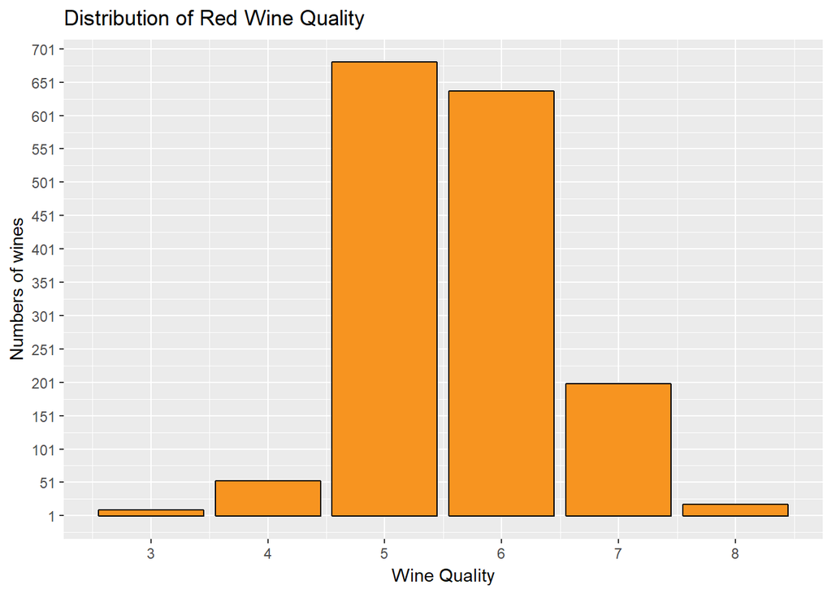

### 描述一

从图中可以看出，红酒quality值主要的还是等于5和6的占多数,并且quality呈现出正态分布. 而且高品质和很低品质的酒数量都很少。

### 绘图二

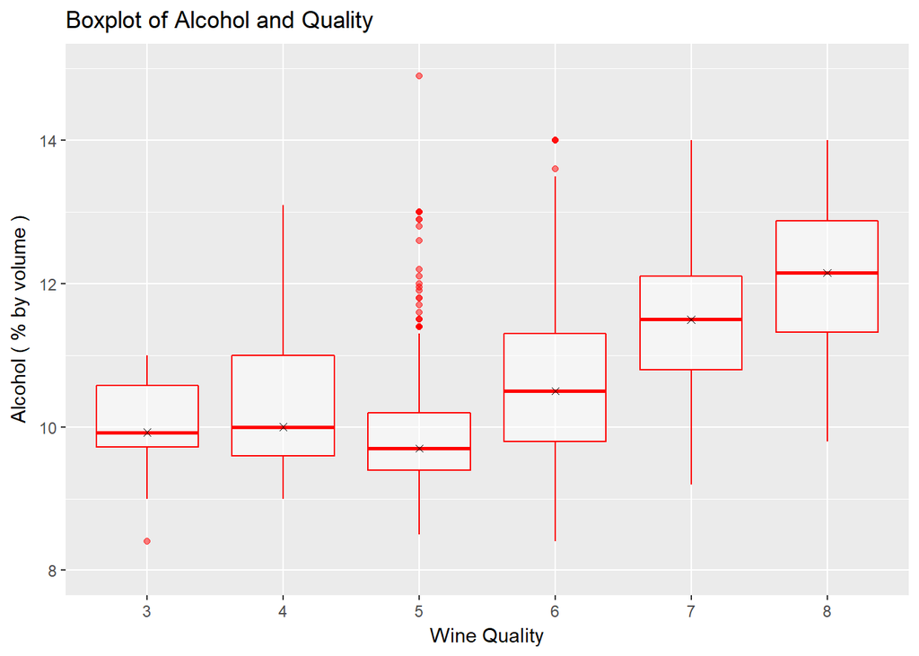

### 描述二

在这里选择了与quality相关性最大的alcohol特性，由于quality值为3，4还有8的数量很少，因此总体上alcohol的值越大，quality值越大，两者呈正相关。而且我们还可以看出alcohol的值集中在9-11度左右。

### 绘图三

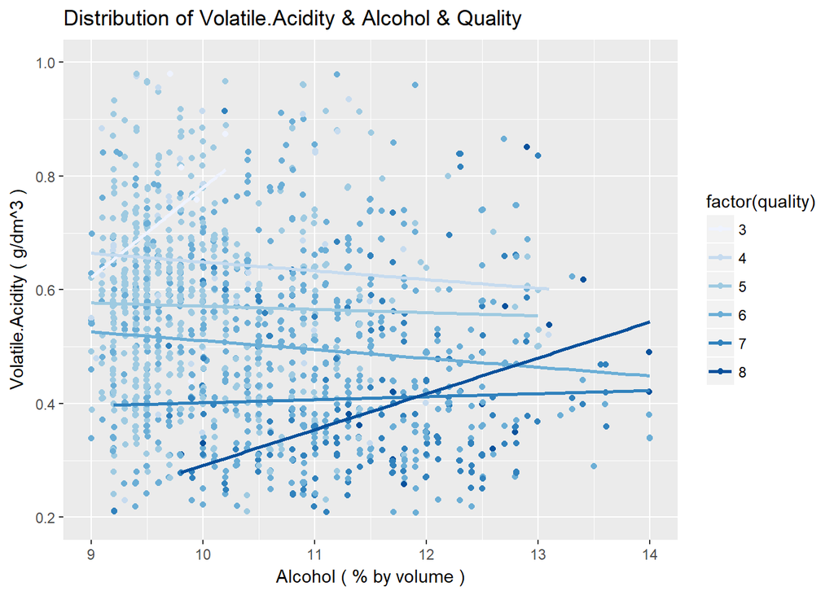

### 描述三

图中可以很清晰的反映出alcohol, volatile.acidity, quality三者之间的关系，从图中可以看出随着alcohol的值增大，fator值大的点数也在变多；然而 volatile.acidity值大的区域内，factor值小的点数比较多。quality与alcohol呈正相关性，与volatile.acidity呈负相关性。换句话就是说alcohol值越大， volatile.acidity值越小，红酒的品质越好。

# 反思

首先我在项目初级犹豫了很久，因为不知道从哪里去入手，一心只想去找一些关系，想能够找到一些比较明显的模型，但是却发现没有上面明显的模型，这让我一下子陷入到无助当中。从单变量分析到双变量分析再到多变量分析的过程中，有时候会因为一些检验，反而影响了判断。比如一开始我认为residual.sugar对红酒的品质有很大影响，结果分析下来发现影响的确很小。所以，在此我觉得有一定的背景知识果然重要，但是面对数据还是要客观地去分析。如果数据没问题，那么分析出来的结果和有可能就是真实的，当然也有可能是一些我们没有注意到的其他因素导致的。总之，对待数据要有严谨的态度。最后在建模阶段，我并没有创建出合适的模型，这也是我感到比较遗憾的，这块的确是我能力还没达到，还要继续去学习机器学习方面的知识。  
在接下来的工作中可能还需要注意以下几点：  
1.这个数据集还是比较小，可以看出质量为5和6的占大多数，数据有点集中，不利于去分析，应该扩大数据集。  
2.在建立模型方面上，应该考虑多尝试几种模型，当然我个人希望在以后能搭建一个神经网络去解决这个问题。